# Homework

By 18069

## Question

Write a .Rmd file to implement at least three examples of different types in the above books (texts, numerical results, tables, and figures).

## Answer

### Example 1

```r
patientID <- c(1,2,3,4)
age <- c(25,34,28,52)
diabetes <- c("Type1","Type2","Type1","Type1")
status <- c("Poor","Improved","Excellent","Poor")
patientdata <- data.frame(patientID,age,diabetes,status)
patientdata
```

```
##   patientID age diabetes    status
## 1         1  25    Type1      Poor
## 2         2  34    Type2  Improved
## 3         3  28    Type1 Excellent
## 4         4  52    Type1      Poor
```

```r
table(patientdata$diabetes,patientdata$status)
```

```
##
##         Excellent Improved Poor
##   Type1         1        0    2
##   Type2         0        1    0
```

### Example 2

```r
mpg <- c(39.4,36.4,33.8,31.5,29.6,27.8,26.3,24.9)
wt <- c(1897,1665,1559,1550,1490,1500,1480,1380)
lm(mpg~wt)
```

```
##
## Call:
## lm(formula = mpg ~ wt)
##
## Coefficients:
## (Intercept)           wt
##   -15.66600      0.02995
```

```r
lmfit <- lm(mpg~wt)
summary(lmfit)
```

```
##
## Call:
## lm(formula = mpg ~ wt)
##
## Residuals:
##      Min       1Q   Median       3Q      Max
## -2.36284 -1.53461 -0.06501  1.10441  2.77096
##
## Coefficients:
##               Estimate Std. Error t value Pr(>|t|)
## (Intercept) -15.666005   7.716671  -2.030 0.088645 .
## wt            0.029952   0.004909   6.102 0.000883 ***
## ---
## Signif. codes:  0 '***' 0.001 '**' 0.01 '*' 0.05 '.' 0.1 ' ' 1
##
## Residual standard error: 2.035 on 6 degrees of freedom
## Multiple R-squared:  0.8612, Adjusted R-squared:  0.8381
## F-statistic: 37.23 on 1 and 6 DF,  p-value: 0.0008831
```

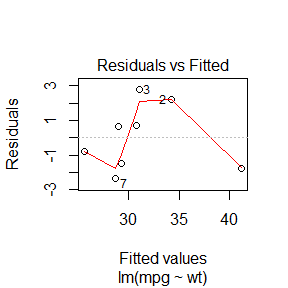

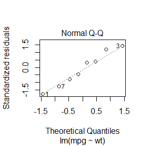

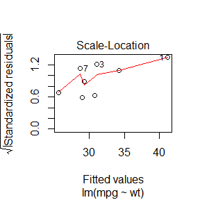

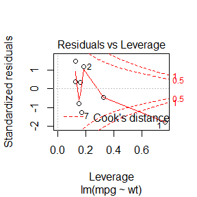

```r
plot(lmfit)
```

## Question 1

A discrete random variable $X$ has probability mass function

| $x$ | 0 | 1 | 2 | 3 | 4 |
| --- | --- | --- | --- | --- | --- |
| $p(x)$ | 0.1 | 0.2 | 0.2 | 0.2 | 0.3 |

Use the inverse transform method to generate a random sample of size 1000 from the distribution of $X$. Construct a relative frequency table and compare the empirical with the theoretical probabilities. Repeat using the R sample function.

## Answer

```r
x <- c(0,1,2,3,4)
p <- c(.1,.2,.2,.2,.3)
cp <- cumsum(p)
m <- 1000
r <- numeric(m);
#find all indexes of x we want under the condition we design: F(x[i-1])<u<=F(x[i])??then x=x[i]
r <- x[findInterval(runif(m),cp)+1]
ct <- as.vector(table(r))
ct
```

```
## [1] 122 193 198 194 293
```

```r
#caculate the probabilty in the random sample we generate
tp <- ct/sum(ct)
ratio <- tp/p
data.frame(x,p,tp,ratio)
```

```
##   x   p    tp     ratio
## 1 0 0.1 0.122 1.2200000
## 2 1 0.2 0.193 0.9650000
## 3 2 0.2 0.198 0.9900000
## 4 3 0.2 0.194 0.9700000
## 5 4 0.3 0.293 0.9766667
```

```r
# #the relative frequency table comparing the empirical with the theoretical probabilities.
```

Next we repeat using the R sample function.

```r
set.seed(1234)
r2 <- sample(c(0,1,2,3,4),m,replace=TRUE,prob=c(.1,.2,.2,.2,.3))
ct2 <- as.vector(table(r2))
tp2 <- ct2/sum(ct2)
ratio <- tp2/p
data.frame(x,p,tp2,ratio)
```

```
##   x   p   tp2 ratio
## 1 0 0.1 0.120 1.200
## 2 1 0.2 0.182 0.910
## 3 2 0.2 0.191 0.955
## 4 3 0.2 0.216 1.080
## 5 4 0.3 0.291 0.970
```

```r
#R sample function
```

## Question 2

Write a function to generate a random sample of size n from the $Beta(a, b)$ distribution by the acceptance-rejection method. Generate a random sample of size 1000 from the $Beta(3,2)$ distribution. Graph the histogram of the sample with the theoretical $Beta(3,2)$ density superimposed.

## Answer

$Beta(3,2)$ with pdf $f(x)=12x^2(1-x),~0<x<1$. Let $c=12$ and $g(x)=x,~0<x<1$.

```r
n <- 1000
j<-k<-0
y <- numeric(n)
while (k < n)
  {
    u <- runif(1)
    j <- j + 1
    x <- runif(1) #random variate from g
    if (x^2 * (1-x) > u)
      {
        #we accept x
        k <- k + 1
        y[k] <- x
      }
   }
j
```

```
## [1] 12066
```

```r
# #(experiments) for n random numbers
```

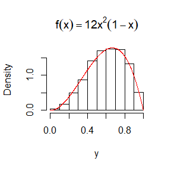

```r
hist(y, prob = TRUE, main = expression(f(x)==12*x^2*(1-x)))
x <- seq(0, 1, .001)
lines(x, 12*x^2*(1-x),col="red")
```

```r
# #Histogram of the sample with the theoretical $Beta(3,2)$ density superimposed,which shows that the random sample generated fits the theoretical model $Beta(3,2)$ well.
```

## Answer

- Exponential-gamma distribution
  - Suppose $X|\Lambda\sim$Exponential($\Lambda$), and $\Lambda\sim$Gamma($r,b$). Then the marginal distribution of $X$ is generalized Pareto distribution with parameter $\xi=1/r$ and $\beta=b/r)$.

```r
library(evir)
```

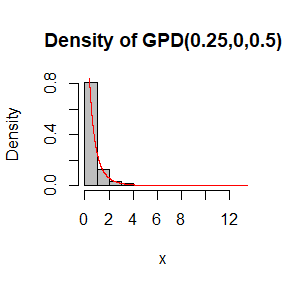

```r
n <- 1000; r <- 4; b <- 2
lambda <- rgamma(n, r, b) #lambda is random
#generate the mixture
x <- rexp(n, lambda)
#compare the mixture with the GPD
hist(x,prob=TRUE,col="grey",main="Density of GPD(0.25,0,0.5)")
y <- seq(0, 100, .001)
lines(y,1/2^4*(1/2+1/4*y)^(-5),col="red") #the density function of generalized Pareto distribution:1/2^4*(1/2+1/4*x)^(-5)
```

```r
# #The figure above shows that the random model generated is good especially when x extends to right further.
```

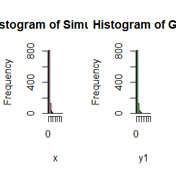

```r
#the theoretical model: generalized Pareto distribution
y1 <- rgpd(n,xi=1/r,mu=0,beta=b/r)
par(mfrow=c(1,2))
hist(x,main="Histogram of Simulation",col="pink")
hist(y1,main="Histogram of GPD",col="light green")
```

```r
# #The comparing histograms shows that the simulation is good.
```

## Question 1

Write a function to compute a Monte Carlo estimate of the $Beta$(3, 3) cdf,and use the function to estimate $F(x)$ for $x = 0.1, 0.2, . . . , 0.9$. Compare the estimates with the values returned by the $pbeta$ function in R.

## Answer

$$Beta(a,b):B(a,b)=\int_0^1x^{a-1}(1-x)^{b-1}dx=E[g(X)]$$

$$g(x)=(1-0)x^{a-1}(1-x)^{b-1}$$

```r
MCofBeta <- function(n,t,a,b){
  x <- runif(n, 0, t)    #generate random x
  theta.hat <- mean(x^(a-1)*(1-x)^(b-1))*t
}
print(c(MCofBeta(1e4,1,3,3),beta(3,3)))   #compare the MC estimation and the theoretical value
```

```
## [1] 0.03295538 0.03333333
```

```r
##the result shows that the MC estimate works well
```

$$F(x;a,b)=\frac{B(x;a,b)}{B(a,b)}$$
$$B(x;a,b)=\int_0^tx^{a-1}(1-x)^{b-1}dx,B(a,b)=\int_0^1x^{a-1}(1-x)^{b-1}dx$$

```r
x <- y <- ratio<-c(.1,.2,.3,.4,.5,.6,.7,.8,.9)
for (i in 1:9){
  F[i] <- MCofBeta(1e4,x[i],3,3)/MCofBeta(1e4,1,3,3)  #generate F(x) based on estimation B(x;a,b)
  y[i]<-pbeta(x[i],3,3)      #theretical value
  ratio[i] <- F[i]/y[i]
}
  data.frame(F,y,ratio)     #compare
```

```
##             F       y     ratio
## 1 0.008653961 0.00856 1.0109768
## 2 0.058798832 0.05792 1.0151732
## 3 0.165073570 0.16308 1.0122245
## 4 0.313431052 0.31744 0.9873710
## 5 0.504825609 0.50000 1.0096512
## 6 0.686506256 0.68256 1.0057816
## 7 0.839889462 0.83692 1.0035481
## 8 0.940439111 0.94208 0.9982582
## 9 0.996510184 0.99144 1.0051140
```

```r
##figure above shows that the MC estimate works well,the ratio is almost equal to 1.
```

## Question 2

The Rayleigh density $[156, (18.76)]$ is
$$f(x) = \frac{x}{\sigma^2}e^{-x^2/(2\sigma^2)}, x\geq0, \sigma > 0.$$
Implement a function to generate samples from a $Rayleigh(\sigma)$ distribution,using antithetic variables. What is the percent reduction in variance of $\frac{X+ X`}2$ compared with $\frac{X_1+ X_2}2$ for independent $X_1, X_2$?

## Answer

Implement the function MC.R to generate samples from $Rayleigh(\sigma)$ distribution
$$\theta=E_U(\frac{x^2U}{\sigma^2}e^{-(Ux)^2/(2\sigma^2)})$$

```r
MC.R <- function(x,sigma,n,antithetic) {
n <- numeric(n)
u <- runif(n/2)       #generate random u ~ U(0,1)

if (!antithetic)
  v <- runif(n/2)     #if not antithentic then generate the other half of n from U(0,1)
else
  v <- 1 - u          #if antithentic then generate the other half of n as 1-u
u <- c(u, v)          #combine the whole u

cdf <- numeric(length(x))
for (i in 1:length(x)) {
  g <- x[i]^2*u/(sigma^2)*exp(-(u *x[i])^2/(2*sigma^2))  #the estimate of x multipling density of Rayleigh for each x
  cdf[i] <- mean(g)   #the estimate of cdf
}
cdf
}
```

The cdf of Rayleigh distribution:$F(x;\sigma)=1-e^{-x^2/{2\sigma^2}},x\geq0$

```r
set.seed(1234)
sigma <- 1;n <- 1e4
x <- R <- seq(.1, 2.5,length=5) #value the x
for(i in 1:length(x))
  R[i] <- 1-exp(-x[i]^2/(2*sigma^2))   #The theoretical cdf of Rayleigh

  MC1 <- MC.R(x,sigma,n,antithetic = FALSE)  #(x1+x2)/2 with independent x1,x2
  MC2 <- MC.R(x,sigma,n,antithetic = TRUE)   #(x+x`)/2 with negatively correlated x,x`

print(round(rbind(x, MC1, MC2, R), 5))
```

```
##        [,1]    [,2]    [,3]    [,4]    [,5]
## x   0.10000 0.70000 1.30000 1.90000 2.50000
## MC1 0.00501 0.21842 0.57370 0.84038 0.96047
## MC2 0.00499 0.21730 0.57045 0.83556 0.95611
## R   0.00499 0.21730 0.57044 0.83553 0.95606
```

```r
##compare the estimate with or without antithetic variables and the theoretical value,which shows that both MC1 and MC2 fit well while MC2 fits better.
```

Next compare the variance and calculate the percent of reduction from MC1 to MC2

```r
set.seed(1234)
m <- 1e2;sigma <- 1;x <- 6;n <- 1e4
MC1 <- MC2 <- numeric(m)
for (i in 1:m) {
MC1[i] <- MC.R(x,sigma,n,antithetic = FALSE)
MC2[i] <- MC.R(x,sigma,n,antithetic = TRUE)
}
var1 <- var(MC1)
var2 <- var(MC2)
ratio <- (var1-var2)/var1   #the percent of reduction
print(c(var1,var2,ratio))
```

```
## [1] 8.902540e-05 2.951537e-05 6.684613e-01
```

## Question 3

Find two importance functions f1 and f2 that are supported on $(1, \infty)$ and are ‘close’ to
$$g(x) = \frac{x^2}{\sqrt{2\pi}}e^{-x^2/2}, x > 1.$$
Which of your two importance functions should produce the smaller variance in estimating
$$\int_1^{\infty}\frac{x^2}{\sqrt{2\pi}}e^{-x^2/2}dx$$
by importance sampling? Explain.

## Answer

$$g(x) = \frac{x^2}{\sqrt{2\pi}}e^{-x^2/2}, x > 1.$$
$$f_1(x)=\frac1{x^2},x>1;f_2(x)=\frac{x}{\sqrt{2\pi}}e^{(1-x^2)/4},x>1$$

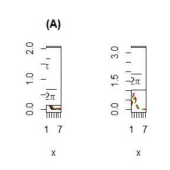

```r
 x <- seq(1,7,.01)
w<-2
g <- exp(-x^2/2)*x^2/sqrt(2*pi)
f1 <- 1/(x^2)
f2 <- x*exp((1-x^2)/4)/sqrt(2*pi)
gs <- c(expression(g(x)==e^{-x^2/2}*x^2/sqrt(2*pi)),expression(f[1](x)==1/(x^2)),expression(f[2](x)==x*e^{(1-x^2)/4}/sqrt(2*pi)))
    #for color change lty to col
    par(mfrow=c(1,2))
    #figure (a)
    plot(x, g, type = "l", ylab = "", ylim = c(0,2),lwd = w,col=1,main='(A)')
    lines(x, f1, lty = 2, lwd = w,col=2)
    lines(x, f2, lty = 3, lwd = w,col=3)
    legend("topright", legend = gs,
           lty = 1:3, lwd = w, inset = 0.02,col=1:3)

    #figure (b)
   plot(x, g/f1,  type = "l",ylim = c(0,3.2),ylab = "",lty = 2, lwd = w,col=2)
    lines(x, g/f2, lty = 3, lwd = w,col=3)
    legend("topright", legend = gs[-1],
           lty = 2:3, lwd = w, inset = 0.02,col=2:3)
```

```r
##The figures above show that f2 is more similiar to g according to figure(A), and it is also more aclinic than f1 in figure(B).f2 is the better estimate than f1.
```

```r
g <- function(x) {x^2*exp(-x^2/2)/sqrt(2*pi)*(x>1)}
m <- 10000   #size
theta.hat <- se <- numeric(2)
#using inverse transform method to generate random sample f1
u <- runif(m)
x <- 1/(1-u)
fg <- g(x)*x^2
theta.hat[1] <- mean(fg)
se[1] <- sd(fg)           #sigma for f1

#using inverse transform method to generate random sample f2
u <- runif(m)
x <- (4*(1-log((1-u)*sqrt(2*pi)/2)))^0.5
fg <- g(x)/(x*exp((1-x^2)/4)/sqrt(2*pi))
theta.hat[2] <- mean(fg)
se[2] <- sd(fg)
rbind(theta.hat,se)
```

```
##                [,1]      [,2]
## theta.hat 0.4005487 0.3975913
## se        0.3069082 0.1761729
```

```r
##As we have inferred in the figures, the data also prensents that f2 is the better function to get closer to g with a smaller variance.
```

## Question 4

Obtain a Monte Carlo estimate of
$$\int_1^{\infty}\frac{x^2}{\sqrt{2\pi}}e^{-x^2/2}dx$$
by importance sampling.

## Answer

We choose the f2 as the f to get close to g according to question 3.
$$f(x)=\frac{x}{\sqrt{2\pi}}exp{(1-x^2)/4}$$
$$\int_1^{\infty}\frac{x^2}{\sqrt{2\pi}}e^{-x^2/2}dx=E(g(x)/f(x))$$

```r
g <- function(x) {x^2*exp(-x^2/2)/sqrt(2*pi)*(x>1)}
m <- 1e7                  #size
u <- runif(m)             #generate the random u ~U(0,1)
x <- (4*(1-log((1-u)*sqrt(2*pi)/2)))^0.5       #using inverse transform method to generate random sample f
fg <- g(x)/(x*exp((1-x^2)/4)/sqrt(2*pi))
theta.hat <- mean(fg)     #the estimate of E(g(x)/f(x)),also the estimate of integral
theta.hat
```

```
## [1] 0.3989977
```

## Question 1

Let X be a non-negative random variable with $?? = E[X] < \infty$. For a random sample $x_1, . . . , x_n$ from the distribution of X, the Gini ratio is defined by
$$G=\frac1{2n^2\mu}\sum_{j=0}^n\sum_{i=1}^n|x_i-x_j|.$$
The Gini ratio is applied in economics to measure inequality in income distribution (see e.g. [163]). Note that G can be written in terms of the order statistics $x_{(i)}$ as
$$G=\frac1{n^2\mu}\sum_{i=1}^n(2i-n-1)x_{i}$$
If the mean is unknown, let $\hat{G}$ be the statistic G with $\mu$ replaced by $\bar{x}$. Estimate by simulation the mean, median and deciles of $\hat{G}$ if X is standard lognormal.Repeat the procedure for the uniform distribution and Bernoulli(0.1). Also construct density histograms of the replicates in each case.

## Answer

```r
GiniEstimation <-  function(cdf,mu,n,m,a,b)  # cdf for the supposed distribution,mu for theoritical expectation,n for size of random numbers,m for repeating times, a and b for the better xlim for histogram(u can choose a better one when u observed its distribution in histogram with random a b )
{
Gcdf<-numeric(m)
set.seed(1234)
v <- numeric(n)

for(i in 1:m)
  {
  x<-sort(cdf(n))     #sort the x

  for(j in 1:n)
    {
    v[j] <- (2*j-n-1)*x[j]
  }
  s <- sum(v)
  Gcdf[i]<-(1/(n^2*mu))*s   #caculate the G for every i
}
mean<-mean(Gcdf)
median<-quantile(Gcdf,0.5)
deciles<-quantile(Gcdf,probs=seq(0,1,0.1))
print(mean)
print(median)
print(deciles)
hist(Gcdf,freq=F,xlim=c(a,b),main="Gini ratio of supposed distribution")  #density histograms of the replicates
}
```

The standard lognormal with theoritical expectation of $X$: $EX=e^{1/2}$

```r
GiniEstimation(rlnorm,exp(0.5),1e3,1e2,0.45,0.65)
```

```
## [1] 0.5224026
##       50%
## 0.5207798
##        0%       10%       20%       30%       40%       50%       60%
## 0.4605035 0.4805966 0.4935186 0.5023262 0.5107198 0.5207798 0.5310809
##       70%       80%       90%      100%
## 0.5383047 0.5527882 0.5635330 0.6023654
```

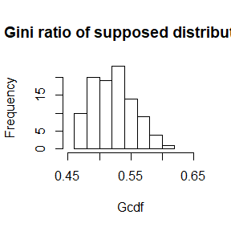

```r
##The mean is much approaching to median as the data shows and we can also roughly conclude from the histogram.
```

The uniform distribution with$X\sim \mathbb{U}(0,1)$$E(X)=0.5$

```r
GiniEstimation(runif,0.5,1e3,1e2,0.32,0.35)
```

```
## [1] 0.3331344
##       50%
## 0.3336176
##        0%       10%       20%       30%       40%       50%       60%
## 0.3224468 0.3268978 0.3282684 0.3298462 0.3320880 0.3336176 0.3347927
##       70%       80%       90%      100%
## 0.3361681 0.3372652 0.3387707 0.3446976
```

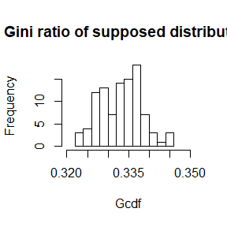

```r
##The mean is much approaching to median as the data shows and we can also roughly conclude from the histogram.
```

The Bernoulli(0.1) distribution with $X\sim Bernoulli(1000,0.1)$$E(X)=100$

```r
n <- m <- 1e3
mu <- 100
Gcdf<-numeric(m)
set.seed(1234)
v <- numeric(n)

for(i in 1:m)
  {
  x<-sort(rbinom(n,1000,0.1))     #sort the x

  for(j in 1:n)
    {
    v[j] <- (2*j-n-1)*x[j]
  }
  s <- sum(v)
  Gcdf[i]<-(1/(n^2*mu))*s   #caculate the G for every i
}
mean<-mean(Gcdf)
median<-quantile(Gcdf,0.5)
deciles<-quantile(Gcdf,probs=seq(0,1,0.1))
print(mean)
```

```
## [1] 0.05348466
```

```r
print(median)
```

```
##        50%
## 0.05349481
```

```r
print(deciles)
```

```
##         0%        10%        20%        30%        40%        50%
## 0.04918666 0.05191771 0.05243589 0.05280906 0.05318438 0.05349481
##        60%        70%        80%        90%       100%
## 0.05381938 0.05416515 0.05444951 0.05507521 0.05799861
```

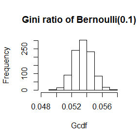

```r
hist(Gcdf,freq=F,xlim=c(0.048,0.058),main="Gini ratio of Bernoulli(0.1)")  #density histograms of the replicates
```

```r
##The mean is much approaching to median as the data shows and we can also roughly conclude from the histogram.
```

## Question 2

Construct an approximate 95% confidence interval for the Gini ratio $\gamma = E[G]$ if X is lognormal with unknown parameters. Assess the coverage rate of the estimation procedure with a Monte Carlo experiment.

## Answer

First we stimulate the $\sigma=sd(logX),logX\sim normal(0,1)$,then we use the$\sigma$to caculate$\gamma$
$$\gamma=E[G]=erf(\sigma/2)=\frac2{\sqrt{\pi}}\int_0^{\frac{\sigma}{2}}e^{-t^2}dt$$
,then we can caculate the CI.

```r
n<-1000              #generate 1000 random numbers
m<-100               #generate 100 gini ratio every times and repeate 100 times
alpha <- 0.05
UCL <- LCL <- numeric(m)
G <- function(b)      #the real value of gamma,b for sigma
  {

  return(2*pnorm(b/sqrt(2))-1)
}
CI.sigma<-function(x,n){                     #function to construct confident interval for sigma
  s2<-(1/(n-1))*sum((x-mean(x))^2)
  LCL<- (n-1)*s2/qchisq(1-alpha/2,n-1)
  UCL<-(n-1)*s2/qchisq(alpha/2,n-1)
  c(LCL,UCL)
}
ciG<-cbind(numeric(m),numeric(m))
C<-CR<-numeric(m)
e <- G(1)
set.seed(1234)
for(j in 1:m){
  for(i in 1:m){

  x<-rlnorm(n)
  ci<-CI.sigma(log(x),n)
  ciG[i,1]<-G(ci[1])
  ciG[i,2]<-G(ci[2])
  if(e>ciG[i,1] && e<ciG[i,2])     # for every ith ci,judge whether real value e in the ci
    C[i]<-1
  else
    C[i]<-0
   }

CR[j]<-mean(C)
}
mean(CR)
```

```
## [1] 0.9544
```

```r
##The coverage rate of estimation is a little bigger than 0.95.
```

## Question 3

Tests for association based on Pearson product moment correlation $\rho$, Spearman??s rank correlation coefficient $\rho_s$, or Kendall??s coefficient $\tau$, are implemented in cor.test. Show (empirically) that the nonparametric tests based on $\rho_s$ or $\tau$ are less powerful than the correlation test when the sampled distribution is bivariate normal. Find an example of an alternative (a bivariate distribution (X, Y ) such that X and Y are dependent) such that at least one of the nonparametric tests have better empirical power than the correlation test against this alternative.

## Answer

Assume $(X,Y)\sim N(\mu,\Sigma)$, with $\mu=(0,0)^T$ and $\Sigma$ is of following:
$$\begin{matrix}
1 & \rho\\
\rho & 1
\end{matrix}$$

Spearman’s rank correlation:

```r
library(MASS)
n <- 20
m <- 1000
rho.s <- c(seq(-0.8,-0.1,0.1),seq(0.1,0.8,0.1))   #alternatives
M <- length(rho.s)
power.s <- numeric(M)
set.seed(1234)
for (i in 1:M) {
rho <-rho.s[i]
pvalues.s <- replicate(m, expr = {       #simulate under alternative mu1
x <- mvrnorm(n, c(0,0), matrix(c(1,rho,rho,1),2,2))
cortest.s <- cor.test(x[,1],x[,2],
alternative = "two.sided",method="spearman")
cortest.s$p.value } )
power.s[i] <- mean(pvalues.s<= .05)
}
power.s
```

```
##  [1] 0.988 0.918 0.743 0.556 0.356 0.231 0.116 0.054 0.058 0.121 0.234
## [12] 0.370 0.564 0.787 0.931 0.985
```

Kendall’s coefficient:

```r
n <- 20
m <- 1000
rho.k <- c(seq(-0.8,-0.1,0.1),seq(0.1,0.8,0.1))    #alternatives
M <- length(rho.k)
power.k <- numeric(M)
set.seed(1234)
for (i in 1:M) {
rho <-rho.k[i]
pvalues.k <- replicate(m, expr = {       #simulate under alternative mu1
x <- mvrnorm(n, c(0,0), matrix(c(1,rho,rho,1),2,2))
cortest.k <- cor.test(x[,1],x[,2],
alternative = "two.sided",method="kendall")
cortest.k$p.value } )
power.k[i] <- mean(pvalues.k<= .05)
}
power.k
```

```
##  [1] 0.988 0.907 0.730 0.550 0.355 0.203 0.107 0.047 0.062 0.116 0.214
## [12] 0.358 0.544 0.778 0.926 0.985
```

Pearson’s correlation:

```r
n <- 20
m <- 1000
rho.p <- c(seq(-0.8,-0.1,0.1),seq(0.1,0.8,0.1))       #alternatives
M <- length(rho.p)
power.p <- numeric(M)
set.seed(1234)
for (i in 1:M) {
rho <-rho.p[i]
pvalues.p <- replicate(m, expr = {     #simulate under alternative mu1

x <- mvrnorm(n, c(0,0), matrix(c(1,rho,rho,1),2,2))
cortest.p <- cor.test(x[,1],x[,2],
alternative = "two.sided",method="pearson")
cortest.p$p.value } )
power.p[i] <- mean(pvalues.p<= .05)
}
power.p
```

```
##  [1] 0.997 0.960 0.827 0.631 0.429 0.257 0.120 0.058 0.069 0.133 0.258
## [12] 0.418 0.650 0.852 0.953 0.991
```

Make comparision

```r
power.rho<-rbind(power.s,power.k,power.p)
colnames(power.rho)<-c(seq(-0.8,-0.1,0.1),seq(0.1,0.8,0.1))
power.rho
```

```
##          -0.8  -0.7  -0.6  -0.5  -0.4  -0.3  -0.2  -0.1   0.1   0.2   0.3
## power.s 0.988 0.918 0.743 0.556 0.356 0.231 0.116 0.054 0.058 0.121 0.234
## power.k 0.988 0.907 0.730 0.550 0.355 0.203 0.107 0.047 0.062 0.116 0.214
## power.p 0.997 0.960 0.827 0.631 0.429 0.257 0.120 0.058 0.069 0.133 0.258
##           0.4   0.5   0.6   0.7   0.8
## power.s 0.370 0.564 0.787 0.931 0.985
## power.k 0.358 0.544 0.778 0.926 0.985
## power.p 0.418 0.650 0.852 0.953 0.991
```

The example $X\sim t_{2}$, $Y\sim U(-1,0)$ when $X<0$ and $Y\sim U(0,1)$ when $X\ge0$.$X,Y$ are dependent.

```r
n <- 20
m <- 1000
set.seed(1234)
pvalues.s1 <- replicate(m, expr = {   #simulate under alternative mu1
x <- rt(n,2)
y<-numeric(n)
for(i in 1:n){
  if(x[i]<0)
    y[i]<-runif(1,-1,0)
  else
    y[i]<-runif(1,0,1)
}
cortest.s1 <- cor.test(x,y,
alternative = "two.sided",method="spearman")
cortest.s1$p.value } )
power.s1 <- mean(pvalues.s1<= .05)
power.s1
```

```
## [1] 0.99
```

```r
##nice power
```

```r
n <- 20
m <- 1000
set.seed(431)
pvalues.p1 <- replicate(m, expr = {
#simulate under alternative mu1
x <- rt(n,2)
y<-numeric(n)
for(i in 1:n){
  if(x[i]<0) y[i]<-runif(1,-1,0)
  else       y[i]<-runif(1,0,1)
}
cortest.p1 <- cor.test(x,y,
alternative = "two.sided",method="pearson")
cortest.p1$p.value } )
power.p1 <- mean(pvalues.p1<= .05)
power.p1
```

```
## [1] 0.849
```

Power of the nonparametric test Spearman’s rank correlation coefficient is much better according to the results.

## Question 1

Compute a jackknife estimate of the bias and the standard error of the correlation statistic in Example 7.2.

## Answer

This question is about the correlation between LSAT and GPA in law data. An unbiased estimate of the bias $E(\hat\theta)-\theta_0$ is
$$(n-1)(\bar{\hat\theta}_{(\cdot)}-\hat\theta)$$
An unbiased estimate of $se(\hat\theta)$ is
$$\sqrt{\frac{n-1}n\sum_{i=1}^n(\hat\theta_{(i)}-\bar{\hat\theta}_{(\cdot)})^2}$$

```r
#declare the varibles
library(bootstrap)
n <-nrow(law)   #sample size
theta.jack <- numeric(n)
```

```r
theta.hat <- cor(law[,1], law[,2]) #law[,1] is LSAT, law[,2] is GPA
b.cor <- function(x,i)cor(x[i,1],x[i,2])
for(i in 1:n)
  {
    theta.jack[i] <- b.cor(law,(1:n)[-i])  #leave one out
}
bias.jack <- (n-1)*(mean(theta.jack)-theta.hat)     #the eatimate bias
se.jack <- sqrt((n-1)*mean((theta.jack-theta.hat)^2))   #the eatimate standard error
round(c(original=theta.hat,bias=bias.jack,se=se.jack),3)
```

```
## original     bias       se
##    0.776   -0.006    0.143
```

```r
##Jackknife estimate of the bias and the standard error of the correlation between LSAT and GPA in law data is shown above.
```

## Question 2

Refer to Exercise 7.4. Compute 95% bootstrap confidence intervals for the mean time between failures $\frac{1}{\lambda}$ by the standard normal, basic, percentile,and BCa methods. Compare the intervals and explain why they may differ.

## Answer

the MLE of $\lambda$:$\hat\lambda=\frac{n}{\sum_{i=0}^{n}x_i}=\frac{1}{\bar{X}}$

```r
#declare the varibles
library(boot)
n <- 100 #sample size
m <- 100# times for replicates
ci.norm<-ci.basic<-ci.perc<-ci.bca<-matrix(NA,m,2)
```

```r
boot.mean <- function(x,i) mean(x$hours[i])
de <- boot(aircondit,statistic=boot.mean,R = 999)
ci <- boot.ci(de,type=c("norm","basic","perc","bca")) #the confidence interval
ci
```

```
## BOOTSTRAP CONFIDENCE INTERVAL CALCULATIONS
## Based on 999 bootstrap replicates
##
## CALL :
## boot.ci(boot.out = de, type = c("norm", "basic", "perc", "bca"))
##
## Intervals :
## Level      Normal              Basic
## 95%   ( 33.8, 180.1 )   ( 25.0, 168.4 )
##
## Level     Percentile            BCa
## 95%   ( 47.8, 191.2 )   ( 56.4, 231.8 )
## Calculations and Intervals on Original Scale
## Some BCa intervals may be unstable
```

```r
##The four kinds of CIs have been shown above,and they differ greatly,it is may beacause of the small fixed sample size which is not appproching the normal distribution.
```

Compare the four kinds of CI

```r
set.seed(4)
mu <- mean(aircondit$hours)#the estimate of mean time
lambda <- 1/mu
tboot.mean <- function(x,i) mean(x[i])
for (i in 1:m) {
  U<-runif(n);R<--log(1-U)/lambda #generate random sample with expotential distribution
  de <- boot(data=R,statistic=tboot.mean, R = 999)
  ci <- boot.ci(de,type=c("norm","basic","perc","bca"))
  ci.norm[i,]<-ci$norm[2:3];ci.basic[i,]<-ci$basic[4:5]
  ci.perc[i,]<-ci$percent[4:5];ci.bca[i,]<-ci$bca[4:5]
}
cat('norm =',mean(ci.norm[,1]<=mu & ci.norm[,2]>=mu),
    'basic =',mean(ci.basic[,1]<=mu & ci.basic[,2]>=mu),
    'perc =',mean(ci.perc[,1]<=mu & ci.perc[,2]>=mu),
    'BCa =',mean(ci.bca[,1]<=mu & ci.bca[,2]>=mu))
```

```
## norm = 0.93 basic = 0.9 perc = 0.94 BCa = 0.93
```

```r
##The result above showS that the percentile method has the best effect in expotential distribution with lambda equals the mle of lambda from aircondit data
```

## Quenstion 3

Refer to Exercise 7.7. Obtain the jackknife estimates of bias and standard error of $\hat\theta$.

## Answer

We have the empirical $\theta$
$$\hat\theta=\frac{\hat\lambda_1}{\sum_{j=0}^{m}\hat\lambda_j}$$
m is the column number of data,$\hat\lambda_j$is the empirical sorted eigenvalue by decreasing order of covariance matrix.

```r
#declare the varibles
library(bootstrap)
n <- nrow(scor)
m <- ncol(scor)
covmatrix <- matrix(NA,m,m)# for covariance matrix
eigenvalues <- lambda <- numeric(m) #for eigenvalues,sorted eigenvalues(decreasing)
```

```r
covmatrix <- cov(scor) #covariance matrix
eigenvalues <- eigen(covmatrix)$values #eigenvalues
lambda <- sort(eigenvalues) #sort the eigenvalues
theta.hat <- lambda[1]/sum(lambda) #the empirical theta
b.theta <- function(x,i)
             {
               covmatrix <- cov(x[i,])
               eigenvalues <- eigen(covmatrix)$values
               lambda <- sort(eigenvalues)
               theta.hat <- lambda[1]/sum(lambda)
             }
for(i in 1:n)
  {
    theta.jack[i] <- b.theta(scor,(1:n)[-i])   #leave one out
  }
bias.jack <- (n-1)*(mean(theta.jack)-theta.hat)     #the eatimate bias
se.jack <- sqrt((n-1)*mean((theta.jack-theta.hat)^2))   #the eatimate standard error
round(c(original=theta.hat,bias=bias.jack,se=se.jack),3)
```

```
## original     bias       se
##    0.029   -0.002    0.004
```

```r
##Jackknife estimate of the bias and the standard error of the theta.hat is shown above.
```

## Quenstion 4

In Example 7.18, leave-one-out (n-fold) cross validation was used to select the best fitting model. Use leave-two-out cross validation to compare the models.

## Answer

```r
#declare the varibles
library(DAAG)
attach(ironslag)
n <- length(magnetic) #in DAAG ironslag
e1 <- e2 <- e3 <- e4 <- numeric(n) # for the prediction error
```

```r
# for n-fold cross validation
# fit models on leave-two-out samples
for (k in 1:round(n/2))
  {
y <- magnetic[-(2*k-1)] #delete the x_2k-1
y <- y[-2*k]          #delete the x_2k
x <- chemical[-2*k-1]
x <- x[-2*k]

J1 <- lm(y ~ x) #Linear model
yhat1.1 <- J1$coef[1] + J1$coef[2] * chemical[2*k-1]
e1[2*k-1] <- magnetic[2*k-1] - yhat1.1
yhat1.2 <- J1$coef[1] + J1$coef[2] * chemical[2*k]
e1[2*k] <- magnetic[2*k] - yhat1.2

J2 <- lm(y ~ x + I(x^2)) #Quardratic model
yhat2.1 <- J2$coef[1] + J2$coef[2] * chemical[2*k-1] +
J2$coef[3] * chemical[2*k-1]^2
e2[2*k-1] <- magnetic[2*k-1] - yhat2.1
yhat2.2 <- J2$coef[1] + J2$coef[2] * chemical[2*k] +
J2$coef[3] * chemical[2*k]^2
e2[2*k] <- magnetic[2*k] - yhat2.2

J3 <- lm(log(y) ~ x) #Exponential model
logyhat3.1 <- J3$coef[1] + J3$coef[2] * chemical[2*k-1]
yhat3.1 <- exp(logyhat3.1)
e3[2*k-1] <- magnetic[2*k-1] - yhat3.1
logyhat3.2 <- J3$coef[1] + J3$coef[2] * chemical[2*k]
yhat3.2 <- exp(logyhat3.2)
e3[2*k] <- magnetic[2*k] - yhat3.2

J4 <- lm(log(y) ~ log(x)) #Log-Log model
logyhat4.1 <- J4$coef[1] + J4$coef[2] * log(chemical[2*k-1])
yhat4.1 <- exp(logyhat4.1)
e4[2*k-1] <- magnetic[2*k-1] - yhat4.1
logyhat4.2 <- J4$coef[1] + J4$coef[2] * log(chemical[2*k])
yhat4.2 <- exp(logyhat4.2)
e4[2*k] <- magnetic[2*k] - yhat4.2
}
c(mean(e1^2), mean(e2^2), mean(e3^2), mean(e4^2))
```

```
## [1] 18.66796 16.33493 17.14092 19.21681
```

```r
##The result above shows that the J2 Model 2, the quadratic model,would be the best fit for the data according to the prediction error criterion.
```

```r
J2
```

```
##
## Call:
## lm(formula = y ~ x + I(x^2))
##
## Coefficients:
## (Intercept)            x       I(x^2)
##    19.15533     -0.77001      0.03697
```

```r
##The related quadratic model is shown above
```

The model is
$$\hat Y=19.15533-0.77001X+0.03697X^2$$

## Question 1

Implement the two-sample Cramer-von Mises test for equal distributions as a permutation test. Apply the test to the data in Examples 8.1 and 8.2.

## Answer

The Cram′er-von Mises statistic
$$W_2=\frac{mn}{(m+n)^2}[\sum_{i=1}^{n}(F_n(x_i)-G_m(x_i))^2+\sum_{j=1}^{n}(F_n(y_j)-G_m(y_j))^2]]$$

```r
#declare the varibles
attach(chickwts)    #for data
x <- sort(as.vector(weight[feed == "soybean"]))
y <- sort(as.vector(weight[feed == "linseed"]))
detach(chickwts)

z <- c(x,y) #pool the sample
m <- length(x);n <- length(y);N <- length(z)
S <- numeric(N) #for Cram′er-von Mises statistic
R<- 999 #number of replicates
W <- k <- numeric(R) #W for storage of replicates k for permutation
```

```r
#caculate the Cram′er-von Mises statistic
cvm <- function(x1,y1){
Fn <- ecdf(x1);Gm <- ecdf(y1);z1 <- c(x1,y1)
for (i in 1:N)
  {
    S[i] <- (Fn(z1[i])-Gm(z1[i]))^2
  }
  m*n/(m+n)^2*sum(S)
  }
W0 <- cvm(x,y)
for (i in 1:R) {
#generate indices k for the first sample
k <- sample(1:N, size = m, replace = FALSE)
x1 <- z[k]
y1 <- z[-k] #complement of x1
W[i] <- cvm(x1,y1)
}
p <- mean(c(W0, W) >= W0)#cacaulate the p value
p
```

```
## [1] 0.385
```

```r
## As the result shows above,it does not support the alternative hypothesis that distributions differ.
```

## Question 2

Design experiments for evaluating the performance of the NN, energy, and ball methods in various situations.

1. Unequal variances and equal expectations
2. Unequal variances and unequal expectations
3. Non-normal distributions: t distribution with 1 df (heavy-tailed distribution), bimodel distribution (mixture of two normal distributions)
4. Unbalanced samples (say, 1 case versus 10 controls)

Note: The parameters should be choosen such that the powers are distinguishable (say, range from 0.3 to 0.9).

## Anwer

```r
#declare the varibles
library(RANN)
library(energy)
library(Ball)
library(boot)
m <- 103; k<-3; p<-2; mu <- 0.5; set.seed(12345)
n1 <- n2 <- 50; R<-999; n <- n1+n2; N = c(n1,n2)
```

```r
Tn <- function(z, ix, sizes,k) {
n1 <- sizes[1]
n2 <- sizes[2]
n <- n1 + n2
z <- z[ix, ]
o <- rep(0, NROW(z))
z <- as.data.frame(cbind(z, o))
NN <- nn2(z, k=k+1)
block1 <- NN$nn.idx[1:n1,-1]
block2 <- NN$nn.idx[(n1+1):n,-1]
i1 <- sum(block1 < n1 + .5)
i2 <- sum(block2 > n1 + .5)
return((i1 + i2) / (k * n))
}
eqdist.nn <- function(z,sizes,k){
  boot.obj <- boot(data=z,statistic=Tn,R=R,
  sim = "permutation", sizes = sizes,k=k)
  ts <- c(boot.obj$t0,boot.obj$t)
  p.value <- mean(ts>=ts[1])
  list(statistic=ts[1],p.value=p.value)
}
p.values <- matrix(NA,m,3)

#Unequal variances and equal expectations
for(i in 1:m){
  x <- matrix(rnorm(n1*p),ncol=p);
  y <- cbind(rnorm(n2),rnorm(n2,mean=mu));
  z <- rbind(x,y)
  p.values[i,1] <- eqdist.nn(z,N,k)$p.value  #NN
  p.values[i,2] <- eqdist.etest(z,sizes=N,R=R)$p.value  #energy method
  p.values[i,3] <-
    bd.test(x=x,y=y,R=R,seed=i*12345)$p.value  #ball method
}
alpha <- 0.05                        #confidence level
pow <- colMeans(p.values<alpha)
pow
```

```
## [1] 0.1456311 0.6116505 0.4271845
```

```r
#Unequal variances and unequal expectations
mu <- 0.6
for(i in 1:m){
  x <- matrix(rnorm(n1*p),ncol=p);
  y <- cbind(rnorm(n2),rnorm(n2,mean=mu));
  z <- rbind(x,y)
  p.values[i,1] <- eqdist.nn(z,N,k)$p.value  #NN
  p.values[i,2] <- eqdist.etest(z,sizes=N,R=R)$p.value  #energy method
  p.values[i,3] <-
    bd.test(x=x,y=y,R=R,seed=i*12345)$p.value  #ball method
}
alpha <- 0.05                        #confidence level
pow <- colMeans(p.values<alpha)
pow
```

```
## [1] 0.2427184 0.7378641 0.5631068
```

```r
#Non-normal distributions: t distribution with 1 df (heavy-tailed distribution), bimodel distribution (mixture of two normal distributions)
for(i in 1:m){
  x <- cbind(rt(n1,1),rnorm(n2, mean = sample(c(0, 1), size = n2, prob = c(0.5, 0.5), replace = T), sd =1 ))
  y <- cbind(rt(n2,1),rnorm(n2, mean = sample(c(1, 2), size = n2, prob = c(0.5, 0.5), replace = T), sd =1 ))
  z <- rbind(x,y)
  p.values[i,1] <- eqdist.nn(z,N,k)$p.value  #NN
  p.values[i,2] <- eqdist.etest(z,sizes=N,R=R)$p.value  #energy method
  p.values[i,3] <-
    bd.test(x=x,y=y,R=R,seed=i*12345)$p.value  #ball method
}
alpha <- 0.05                        #confidence level
pow <- colMeans(p.values<alpha)
pow
```

```
## [1] 0.5048544 0.5922330 0.5242718
```

```r
#Unbalanced samples (say, 1 case versus 10 controls)
n1 <- 10;n2 <- 1e2;N = c(n1,n2)
for(i in 1:m){
  x <- matrix(rnorm(n1*p),ncol=p);
  y <- cbind(rnorm(n2),rnorm(n2,mean=mu));
  z <- rbind(x,y)
  p.values[i,1] <- eqdist.nn(z,N,k)$p.value  #NN
  p.values[i,2] <- eqdist.etest(z,sizes=N,R=R)$p.value  #energy method
  p.values[i,3] <-
    bd.test(x=x,y=y,R=R,seed=i*12345)$p.value  #ball method
}
alpha <- 0.05                        #confidence level
pow <- colMeans(p.values<alpha)
pow
```

```
## [1] 0.1553398 0.3106796 0.1844660
```

## Question 3

Use the Metropolis-Hastings sampler to generate random variables from a standard Cauchy distribution. Discard the first 1000 of the chain, and compare the deciles of the generated observations with the deciles of the standard Cauchy distribution (see qcauchy or qt with df=1). Recall that a $Cauchy(\theta, \eta)$ distribution has density function
$$f(x) =\frac{1}
{\theta\pi(1 + [(x- \eta)/\theta]^2)}, - \infty < x < \infty, \theta>0.$$
The standard Cauchy has the $Cauchy(\theta= 1, \eta = 0)$ density. (Note that the standard Cauchy density is equal to the Student t density with one degree of freedom.)

## Answer

```r
#declare the varibles
library(stats)
theta <- 1;eta <- 0
m <- 10000
x <- numeric(m)
```

```r
f <- function(x, theta,eta) {
if (theta > 0)
return(1/(theta*pi*(1+((x-eta)/theta)^2)))
}

x[1] <- runif(1,min=-1,max=1)
k <- 0
u <- runif(m)
for (i in 2:m) {
xt <- x[i-1]
y <- xt+runif(1,min=-1,max=1) #proposal distribution
num <- f(y, theta,eta) * dnorm(xt, mean = y,sd=0.5)

den <- f(xt, theta,eta) * dnorm(y, mean = xt,sd=0.5)

if (u[i] <= num/den) x[i] <- y
else {
x[i] <- xt
k <- k+1 #y is rejected
}
}
print(k)
```

```
## [1] 1425
```

Compare the deciles of the generated observations with the deciles of the standard Cauchy distribution

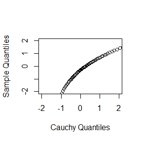

```r
b <- 1001 #discard the burnin sample
y <- x[b:m]
a <- ppoints(100)
QC <- qcauchy(a) #quantiles of Cauchy
Q <- quantile(x, a)
qqplot(QC, Q, main="",xlim=c(-2,2),ylim=c(-2,2),xlab="Cauchy Quantiles", ylab="Sample Quantiles")
```

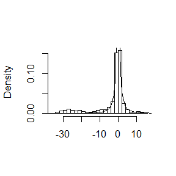

```r
hist(y, breaks="scott", main="", xlab="", freq=FALSE)
lines(QC, f(QC,theta,eta))
```

## Question 4

Rao $[220, Sec. 5g]$ presented an example on genetic linkage of 197 animals in four categories (also discussed in $[67, 106, 171, 266])$. The group sizes are $(125, 18, 20, 34)$. Assume that the probabilities of the corresponding multinomial distribution are
$$(\frac12+\frac{\theta}{4},\frac{1-\theta}4,\frac{1-\theta}4,\frac{\theta}4).$$
Estimate the posterior distribution of $\theta$ given the observed sample, using one of the methods in this chapter.

## Answer

```r
#declare the varibles
gsize <- c(125,18,20,34)  #group size
m <- 5000
w <- .25
burn <- 1000
```

```r
#the target density
prob <- function(y, gsize) {
  if (y < 0 || y >1)
    return (0)
  else
  return((1/2+y/4)^gsize[1] *((1-y)/4)^gsize[2]*((1-y)/4)^gsize[3]*(y/4)^gsize[4])
}

u <- runif(m)  #for accept/reject step
v <- runif(m, -w, w)  #proposal distribution
x[1] <- .25
for (i in 2:m) {
  y <- x[i-1] + v[i]
  if (u[i] <= prob(y, gsize) / prob(x[i-1], gsize))
    x[i] <- y
  else
    x[i] <- x[i-1]
}
xtheta <- x[(burn+1):m]
theta.hat <- mean(xtheta)
theta.hat
```

```
## [1] 0.6199813
```

```r
##the estimate of posterior distribution of θ is shown above.
```

## Question 4

Rao [220, Sec. 5g] presented an example on genetic linkage of 197 animals in four categories (also discussed in [67, 106, 171, 266]). The group sizes are 278 Statistical Computing with R (125, 18, 20, 34). Assume that the probabilities of the corresponding multinomial distribution are
$$(\frac{1}{2}+\frac{\theta}{4},\frac{1-\theta}{4},\frac{1-\theta}{4},\frac{\theta}{4}).$$
Estimate the posterior distribution of theta given the observed sample, using one of the methods in this chapter.

## Answer

```r
#declare the varibles
gsize <- c(125,18,20,34)  #group size
m <- 5000
w <- .25
burn <- 1000
x <- numeric(m)
```

```r
#the target density
prob <- function(y, gsize) {
  if (y < 0 || y >1)
    return (0)
  else
  return((1/2+y/4)^gsize[1] *((1-y)/4)^gsize[2]*((1-y)/4)^gsize[3]*(y/4)^gsize[4])
}

u <- runif(m)  #for accept/reject step
v <- runif(m, -w, w)  #proposal distribution
x[1] <- .25
for (i in 2:m) {
  y <- x[i-1] + v[i]
  if (u[i] <= prob(y, gsize) / prob(x[i-1], gsize))
    x[i] <- y
  else
    x[i] <- x[i-1]
}
x
```

[output not shown]

[output cut: 819 more lines]

```r
xtheta <- x[(burn+1):m]
theta.hat <- mean(xtheta)
theta.hat
```

```
## [1] 0.6227168
```

```r
##the estimate of posterior distribution of theta is shown above.
```

## Question 1

Write a function to compute the cdf of the Cauchy distribution, which has density
$$\frac{1}{\theta\pi(1+[(x-\eta)/\theta]^2)},-\infty<x<\infty$$
where$\theta>0$. Compare your results to the results from the R function pcauchy.(Also see the source code in pcauchy.c.)